## Background

Donald Trump, arguably America’s most controversial president, is the most-followed world leader on Twitter today, with more than 42 million followers. His unorthodox use of social media often results in headliner tweets that have sparked debate. Trump has shared his stance on the issue, once again turning to his preferred method of communication to post the following: “My use of social media is not Presidential- it’s MODERN DAY PRESIDENTIAL. …”

Regardless, the twitter account of the 45th President of the United States is a unique source of information. This study is a brief sentiment analysis of Trump’s tweets.

## Data

The Twitter data is downloaded manually from **Trump Twitter Archive:** http://www.trumptwitterarchive.com/archive

The date and the time of the most recent tweet that is included in this study: 11/5/17 20:06

## Method

The Twitter data is cleaned and manipulated to extract every word with its corresponding timestamp.

The sentiment analysis is conducted in R using the “NRC Word-Emotion Association Lexicon”.

## Results

- The ten most frequently-used words:

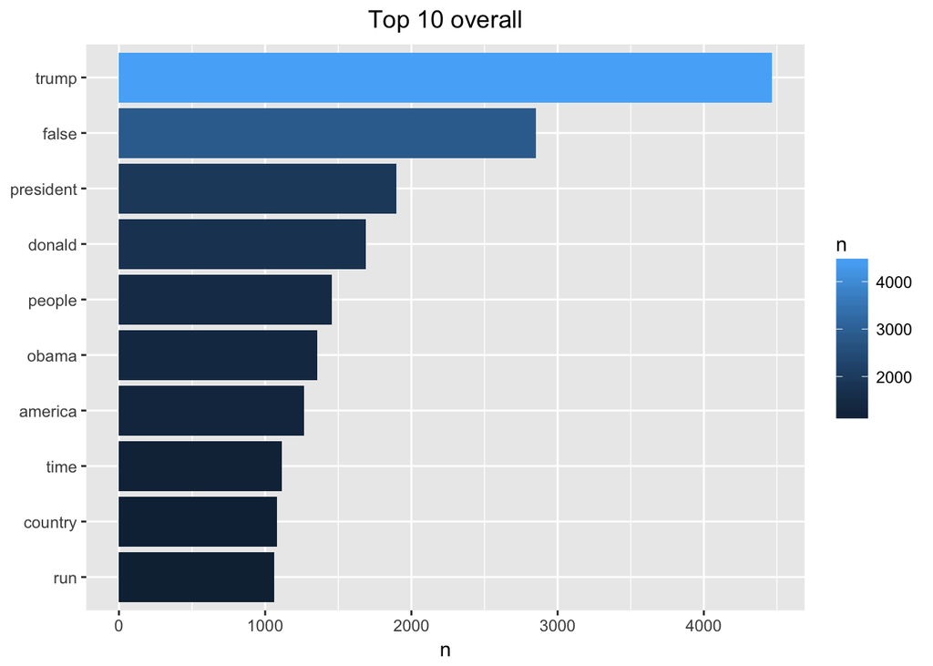

- The wordclouds corresponding to the last four years, where every word is weighted based on frequency:

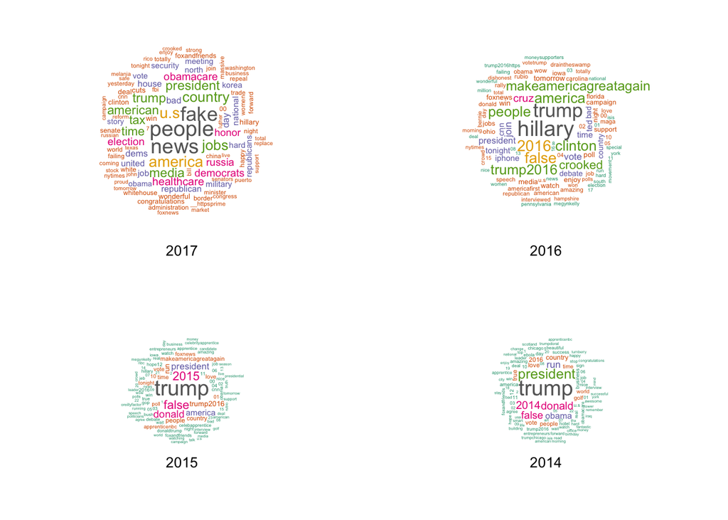

- The five most frequently-used words for each sentiment and emotion:

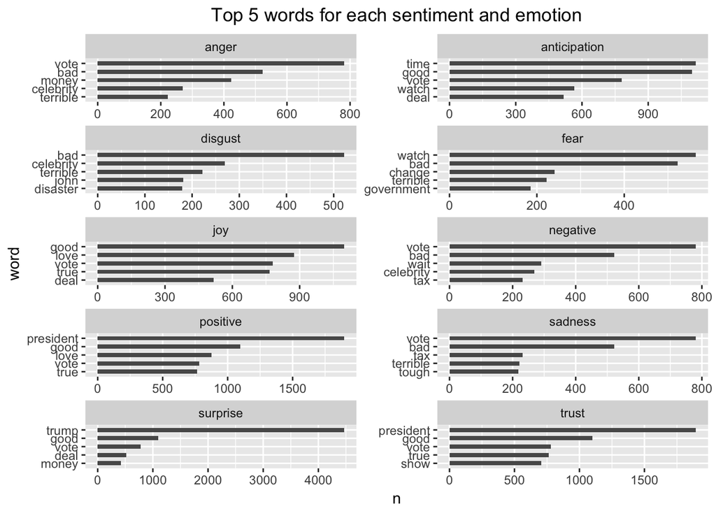

- The ten most frequently-used positive and negative words:

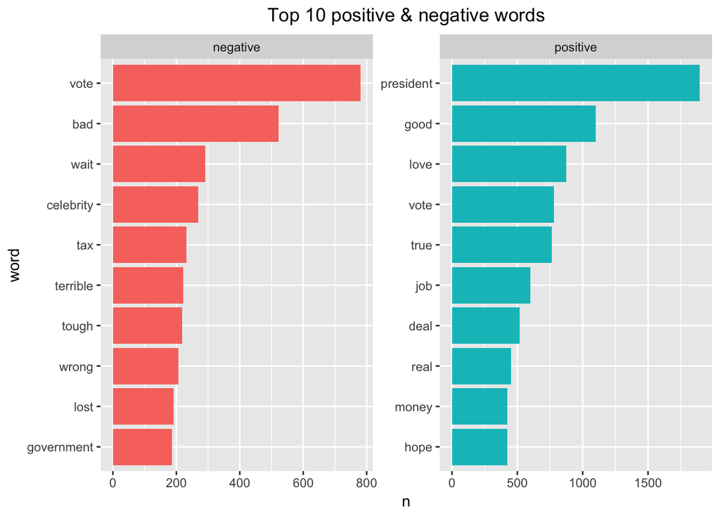

- The positive and negative sentiment changes per six months over time:

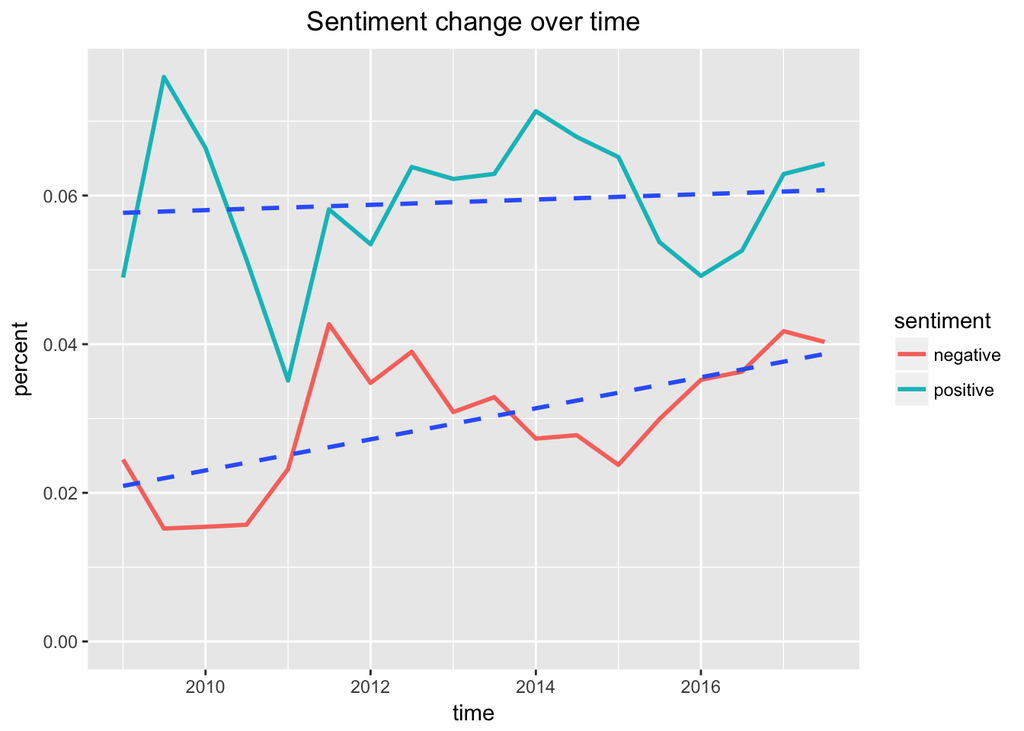

## Limitations and Further Research

- Some limitations of this study:
  - The data cannot be downloaded directly from the website, making it difficult to create and update the dataset automatically. The task of cleaning the data and extracting the words is complicated by the fact that the Tweet texts appear with extra source information. A better source of data could facilitate the process and allow for a more reproducible analysis.
  - Trump’s tweets frequently feature misspellings. As a result, some words do not find their counterparts in the lexicon.
  - It was a challenge to decide whether or not to filter out the hashtags or references of Twitter accounts. For this analysis, I chose to only filter out Trump’s personal account, @realDonaldTrump.
- Further research may include:
  - analysis of Trump’s interaction with other Twitter users
  - sentiment analysis to gauge his reaction to events as they unfold
  - speech pattern assessment and predicton of future tweets